# Autistic traits are associated with faster pace of aging: Evidence from the Dunedin study at age 45 - Mason - 2021 - Autism Research - Wiley Online Library

[Autism Research](https://onlinelibrary.wiley.com/journal/19393806)

[Volume 14, Issue 8](https://onlinelibrary.wiley.com/toc/19393806/2021/14/8) p. 1684-1694

[figure not shown]

RESEARCH ARTICLE

Open Access

# Autistic traits are associated with faster pace of aging: Evidence from the Dunedin study at age 45

[David Mason](https://onlinelibrary.wiley.com/authored-by/Mason/David),

[Angelica Ronald](https://onlinelibrary.wiley.com/authored-by/Ronald/Angelica),

[Antony Ambler](https://onlinelibrary.wiley.com/authored-by/Ambler/Antony),

[Avshalom Caspi](https://onlinelibrary.wiley.com/authored-by/Caspi/Avshalom),

[Renate Houts](https://onlinelibrary.wiley.com/authored-by/Houts/Renate),

[Richie Poulton](https://onlinelibrary.wiley.com/authored-by/Poulton/Richie),

[Sandhya Ramrakha](https://onlinelibrary.wiley.com/authored-by/Ramrakha/Sandhya),

[Jasmin Wertz](https://onlinelibrary.wiley.com/authored-by/Wertz/Jasmin),

[Terrie E. Moffitt](https://onlinelibrary.wiley.com/authored-by/Moffitt/Terrie+E.),

[Francesca Happé](https://onlinelibrary.wiley.com/authored-by/Happ%C3%A9/Francesca),

First published: 27 May 2021

https://doi.org/10.1002/aur.2534

Citations: 6

**Funding information:** Jacobs Foundation; Medical Research Council, Grant/Award Number: MR/P005918; National Institute on Aging, Grant/Award Numbers: R01AG032282, R01AG049789; New Zealand Health Research Council, Grant/Award Number: 15-265

## Abstract

### Lay Summary

The role that autistic traits have in relation to health outcomes has not been investigated. We looked at how physical health and aging (measured with self-reported questions and decline in multiple biological measures) were related to autistic traits (measured with a questionnaire, at age 45). We found that higher autistic traits were associated with poorer reports of physical health, and a faster pace of aging. This suggests that both those with autism and those with higher autistic traits may be more likely to experience poorer health outcomes.

## INTRODUCTION

There is a small, but expanding, research literature about the physical health status of autistic people (Cashin et al., 2018). Autism Spectrum Disorder (ASD; hereafter “autism,” “autistic people,” or “on the autism spectrum”; Kenny et al., 2016) is a neurodevelopmental condition characterized by atypical social and communication style and restricted interests and/or repetitive behaviors (American Psychological Association, 2013). Autism is associated with neurological conditions, and with elevated rates of both psychiatric and physical health comorbidities. Autistic people are more likely to experience premature mortality; approximately 12 years earlier for people on the autism spectrum and 30 years earlier for those with co-occurring intellectual disability (Hirvikoski et al., 2016). Several studies have reported elevated rates of a range of physical health conditions across the lifespan. One study of electronic health records with autistic children (aged 3 to 9) reported elevated rates of autoimmune, endocrine, and genetic disorders compared to age and gender-matched comparison samples (*N* = 3926 and *N* = 39,224 respectively; Cummings et al., 2016), and the same study found elevated rates of endocrine and genetic disorders in autistic adolescents (*N* = 4399 and *N* = 43,951 matched comparison participants; Cummings et al., 2016). This is consistent with parental report, with parents reporting greater rates of bone, joint, or muscle problems, food allergies, and hearing or vision problems in autistic children compared to nonautistic children (Gurney et al., 2006). In adulthood, a large study from Northern California examined medical insurance records and found that autistic adults (*N* = 1507) had elevated rates of a range of age-related health conditions compared with matched controls (*N* = 15,070), including: cardiovascular disease (OR = 2.54), diabetes (OR = 2.18), Parkinson's disease (and spectrum; OR = 32.7), nutrition conditions (e.g., vitamin deficiency, OR = 2.68), and obesity (OR = 1.41) (Croen et al., 2015). Consistent with this, a separate study found elevated rates of physical conditions, notably seizures and hypertension, in a survey of 255 autistic adults (aged 18 to 71; Fortuna et al., 2016). Further, two studies using Scottish census data reported elevated rates of physical disability, sight and hearing loss in autistic adults (Rydzewska et al., 2018; Rydzewska et al., 2019).

Despite rates of physical health conditions being elevated in samples of autistic children and adults across the lifespan, it is notable that several of the physical disorders elevated in autism are generally more prevalent with advancing age. There is a conspicuous lack of research about the aging process and autism (Happé & Charlton, 2012; Wright et al., 2019). This may be because the earliest research cohorts of autistic children are only now reaching older adulthood (Mukaetova-Ladinska & Stuart-Hamilton, 2016), and many older autistic people go undiagnosed; the so-called ‘missing generation’ (Barnhill, 2007). The few studies of older autistic adults have reported primarily on cognition and mental health (e.g., Lever & Geurts, 2016; Uljarević et al., 2019). To date there is only one study of physical health focused on older autistic people; a retrospective cohort study of Medicare records from 4685 autistic adults aged 65 or older reported elevated rates of age-related conditions including osteoporosis, osteoarthritis, heart disease, cancer, and cerebrovascular disease (Hand et al., 2020). These findings raise the possibility that the pace of aging (described below) is accelerated in autism, increasing the risk of age-related health problems.

Pace of aging reflects declining function across a range of bodily systems including cardiovascular, metabolic, renal, immune, dental, and pulmonary systems (Moffitt et al., 2017). Hence, pace of aging taps individual changes in biological processes rather than simply measuring chronological age (Belsky et al., 2017); two people of the same age may differ radically in their pace of aging.

To date, studies have explored health outcomes or mortality using a categorical distinction between those clinically diagnosed with autism and matched controls. There is growing evidence, however, that the characteristics associated with autism (social and communication difficulties, repetitive behaviors), as measured by self-report instruments such as the Autism Quotient (AQ; Allison et al., 2012), are continuously distributed in the general population (Constantino & Charman, 2016; Ruzich et al., 2015). Twin studies suggest that the same genetic influences act on diagnosed autism, extreme autistic traits, and subclinical autistic traits (Colvert et al., 2015; Lundström et al., 2012; Robinson, Koenen, et al., 2011; Ronald et al., 2006) and molecular genetic studies concur with these findings (Massrali et al., 2019; Robinson et al., 2016; Stergiakouli et al., 2017). A twin-study comparing co-twins with, and without an autism diagnosis found that neurological conditions (epilepsy, vertigo, headache, brain injury, and hearing impairment) were associated with autistic traits (however, immunological conditions were not; Pan et al., 2019). A recent study found that adults (aged 50 years or older, mean age 62 years) who self-reported high autistic traits were more likely than those without such traits to experience difficulties with sleep, depression, and anxiety (Stewart et al., 2020b). Thus, taking a dimensional approach to autistic traits may provide additional information about physical health and the pace of aging in autism.

The present study investigated the association between autistic traits and several markers of aging (pace of aging, facial age, self-, informant-, and interviewer-rated health) measured at age 45, accounting for childhood and adulthood demographics. Specifically, we hypothesized that: (a) autistic traits would be associated with a faster pace of aging; (b) autistic traits would be associated with older facial age; and (c) autistic traits would be associated with poorer self-, informant- and interviewer-rated health.

## METHODS

### *Sample*

Participants are members of the Dunedin Study, a longitudinal investigation of health and behavior in a representative birth cohort. The 1037 participants (91% of eligible births, the remaining 9% declined participation, or were unable to participate; Poulton et al., 2015) were all individuals born between April 1972 and March 1973 in Dunedin, New Zealand, who were eligible on the basis of residence in the province and who participated in the first assessment at age 3 years (Poulton et al., 2015). The cohort represents the full range of socioeconomic status (SES) in the general population of New Zealand's South Island and, as adults, matches the New Zealand National Health and Nutrition Survey on key adult health indicators (e.g., body mass index, smoking, and general practitioner visits) and the New Zealand Census of citizens of the same age on educational attainment (Poulton et al., 2015). The cohort is primarily white (93%, self-identified), matching South Island demographic characteristics. Assessments were performed at birth; at ages 3, 5, 7, 9, 11, 13, 15, 18, 21, 26, 32, and 38 years; and, most recently (completed April 2019), at age 45 years, when 938 of the 997 participants (94.1%) still alive participated. Of the 938 participants who took part, 23 did not have AQ-10 data (see Measures), and so were excluded. Therefore, the final sample comprised 915 participants. Study members with data available at age 45 years did not differ significantly from other living participants in terms of childhood SES and childhood IQ (Carlisi et al., 2020). At each assessment, each participant was brought to the research unit for interviews and examinations. Research staff (hereafter “interviewer”) make standardized ratings, informant questionnaires are collected, and administrative records are searched.

### *Measures*

Autism Quotient-10 (AQ-10; Allison et al., 2012): This is a 10-item adaptation of the longer 50-item AQ, designed to screen for autistic traits in children and adults. Self-report questions tap behaviors or cognitions characteristic of ASD, such as attention to detail (e.g., “I usually concentrate more on the whole picture, rather than the small details”), attention switching (e.g., “I find it easy to do more than one thing at once”), or communication (e.g., “I find it easy to ‘read between the lines’ when someone is talking to me” reverse coded). Each item is answered on a 4-point Likert scale (strongly disagree, disagree, agree, strongly agree). When scoring, responses are dichotomised to give a 1 or 0 score (i.e., “strongly agree” and “agree” responses would be collapsed and scored 1 for an item that indicates an autistic trait). The measure is a short form of the full AQ, which was intended to capture 5 constructs (detail focus, attention switching, communication, imagination, and social). However, we opted to use only the total score. Greater scores indicate more autistic traits; a score of 6 indicates a potential need for a full autism diagnostic assessment (Allison et al., 2012). The sensitivity and specificity of the AQ-10 have been reported as 79.9% and 87.3%, respectively (in a sample comprised of autistic and general population participants; Booth et al., 2013). Cronbach's alpha for those completing the measure was 0.60, indicating acceptable internal reliability, albeit somewhat lower than other published studies with general population samples (e.g., 0.85, Allison et al., 2012; 0.67 to 0.73, depending on age, Lundin et al., 2019).

Demographic data: The SES of participants' childhood families was measured using the six-point Elley-Irving Socioeconomic Index for New Zealand (Elley & Irving, 1976). This measure was derived from Statistics New Zealand, from their census, and includes income, education level, and prestige for each occupation in New Zealand. Childhood SES represented the average of the highest SES level of either parent across the assessments of cohort families from the study member's birth through age 15 years (M = 3.8, *SD* = 1.1, range = 1 to 6).

Childhood IQ data were obtained from assessments conducted when participants were aged 7, 9, and 11 years. Full scale IQ scores were assessed using the Wechsler Intelligence Scale for Children- Revised (WISC-R; Wechsler, 1974). Scores were averaged across the three childhood assessments to yield a childhood IQ score.

Pace of aging: This was measured for each Dunedin participant with repeated assessments of an established panel of 19 biomarkers taken at ages 26, 32, 38, and 45 years, and employed as previously described (Belsky et al., 2015; Elliott et al., 2021). The 19 biomarkers cover the main aspects of aging and were as follows: body mass index, waist-hip ratio, glycated hemoglobin, leptin, mean arterial pressure, cardiorespiratory fitness, forced expiratory volume in 1 s (FEV1), FEV1 to forced vital capacity ratio, total cholesterol, triglycerides, high-density lipoprotein cholesterol, apolipoprotein B100/A1 ratio, lipoprotein(a), creatinine clearance, urea nitrogen, C-reactive protein, white blood cell count, mean periodontal attachment loss (AL), and caries-affected tooth surfaces. Measures were taken in counterbalanced order across participants except for blood and dental examinations which were both conducted in the late afternoon at all four phases. Women who were pregnant at the time of a given assessment were included in that wave of data collection, except blood biomarkers were not collected. Change over time in each biomarker was modeled with mixed-effects growth models, and these rates of change were combined into a single index scaled (within sex) in years of physiological change occurring per one chronological year using a previously described method (Belsky et al., 2015). Briefly, the biomarkers were standardized to a mean of 0 and *SD* of 1 based on the age 26 distributions. Mixed effect growth models were used to estimate each participants' slope over the four study occasions for each biomarker individually. These slopes were then summed and scaled so that 1 year of chronological age equated roughly to 1 year of average change in physiological functioning in the sample. Participants ranged in their Pace of Aging from 0.4 years of physiological change (slow aging) per chronological year to 2.4 years of physiological change per chronological year (fast aging).

Facial aging: Facial age is a valid biomarker of aging that predicts mortality above and beyond other relevant measures of health, as shown in MZ co-twins discordant for facial age (Christensen et al., 2009). The measure was based on two measurements of perceived age using ratings of each participant's facial photograph by an independent panel of eight raters. First, Age Range was assessed by an independent panel of four raters, who were presented with standardized (non-smiling) facial photographs of participants and were kept blind to their actual age. Raters used a Likert scale to categorize each participant into a 5-year age range (i.e., from 20 to 24 years old up to 70+ years old) (interrater reliability = 0.77). Scores for each participant were averaged across all raters. Second, Relative Age was assessed by a different panel of four raters, who were told that all photos were of people aged 45 years old. Raters then used a seven-item Likert scale to assign a “relative age” to each participant (1 = “young looking,” 7 = “old looking”) (interrater reliability = 0.79). The measure of perceived age at 45 years was derived by standardizing and averaging age range and relative age scores.

Perceived health: We obtained three reports about study members' health from three sources: self-reports, informant impressions, and interviewer impressions. Interviewers met with study participants for an hour of data collection. As part of the data collection a multi-item checklist was used by the interviewer, about the study member. The item used to measure interviewer-rated health was “In general, how is SMs health?” (response options: poor, fair, good, very good, excellent). Each study member identified three people who could act as informants about them (i.e., someone who knows them well). Each informant is then asked to complete a series of questionnaires about the study member (95% had at least one informant questionnaire completed; 60% had all three completed). The item used to measure informant-rated health was “How would you rate their fitness?” (response option: poor, fair, good, very good, excellent). Correlations between self-, informant-, and interviewer-ratings ranged from 0.48 to 0.55.

### *Data analysis*

The study's preregistration materials can be accessed online at https://sites.google.com/site/moffittcaspiprojects/home/projectlist/happe_2019. All continuous variables were inspected for normality using histograms and descriptive statistics (skew and kurtosis). Pearson's correlations were used to investigate the associations between AQ-10 score and the dependent variables of adulthood aging and health variables (pace of aging, facial age, self-reported health, informant-rated health, and interviewer-rated health). To control for spurious associations due to low IQ or SES present from childhood, multiple regression was used to test whether AQ-10 score statistically predicted the aging and health variables over and above the effects of these childhood variables (childhood IQ, childhood SES and sex). We did not include SES in adulthood because this was coded based on occupation at age 45 which may be a consequence of elevated autistic traits; thus, adulthood SES is not a variable in need of statistical control to address the present research question. All analyses were conducted in SPSS version 25 (IBM Corp., 2017); JASP version 0.13.1 (JASP Team, 2020) was used to calculate effect sizes with confidence intervals.

## RESULTS

As expected, males reported significantly higher AQ-10 scores than females (mean = 2.0, *SD* = 1.7 and mean = 1.5, *SD* = 1.7, respectively; t[913] = 5.2, *p* < 0.001), but the effect size was small (Cohen's d = 0.34). Child and adult data for the study participants with AQ-10 data are shown in Table 1. Note, due to incomplete data, the sample size for each measure is different. Sample size ranges from *N* = 877 for informant-rated health, to 915 for self-rated health and AQ-10.

TABLE 1. Number of participants, mean (*SD*), and range for each study variable collected from Dunedin study participants

| Variable |  | N | Mean | *SD* | Range |
| --- | --- | --- | --- | --- | --- |
| AQ-10 score at age 45 years | Self-reported | 915 | 1.7 | 1.7 | 0–10 |
| Full scale IQ | Childhood<sup>a</sup> | 904 | 100.7 | 14.0 | 45.0–140.7 |
| Socio economic status | Childhood<sup>b</sup> | 910 | 3.8 | 1.1 | 1–6 |
| Biological aging variables | Pace of aging<sup>c</sup> | 913 | 1.0 | 0.3 | 0.4–2.4 |
|  | Facial age<sup>d</sup> | 900 | 0.0 | 1.0 | −2.9–3.1 |
| Health variables | Self-reported | 915 | 3.7 | 0.9 | 1–5 |
|  | Informant-reported | 877 | 3.8 | 0.8 | 1–5 |
|  | Interviewer-rated | 915 | 3.3 | 0.7 | 1–5 |

- <sup>a</sup> Aggregated WISC-R scores from ages 7, 9, and 11.
- <sup>b</sup> Aggregated from the participant's childhood family from birth through to age 15.
- <sup>c</sup> Aggregated from 19 biomarkers collected at 26, 32, 38, and 45, represents number of years aged per chronological age.
- <sup>d</sup> z-score.

### *Are autistic traits associated with physical health and aging?*

AQ-10 total score was significantly correlated with each dependent variable. People who reported more autistic traits at age 45 tended to have a faster pace of aging (*r* = 0.16, *p* < 0.001), older facial age (*r* = 0.14, *p* < 0.001), worse self-reported health (*r* = −0.21, *p* < 0.001), poorer informant-rated health (*r* = −0.13, *p* < 0.001), and poorer interviewer-rated health (*r* = −0.22, *p* < 0.001). See Table 2 for intercorrelations between study variables (see Table S1 for correlations between AQ-10 total, pace of aging, facial age, self-, interviewer-, and informant-rated health, controlling for childhood SES and childhood IQ, and Figure S2 for plots of these relationships).

TABLE 2. Correlations between AQ-10, childhood characteristics, aging, and health variables

|  |  | 1 | 2 | 3 | 4 | 5 | 6 | 7 | 8 |
| --- | --- | --- | --- | --- | --- | --- | --- | --- | --- |
| 1 | AQ-10 | 1.000 |  |  |  |  |  |  |  |
| 2 | Childhood SES | −0.139** | 1.000 |  |  |  |  |  |  |
| 3 | Childhood IQ | −0.239** | 0.410** | 1.000 |  |  |  |  |  |
| 4 | Pace of aging | 0.155** | −0.246** | −0.293** | 1.000 |  |  |  |  |
| 5 | Facial age | 0.136** | −0.244** | −0.251** | 0.326** | 1.000 |  |  |  |
| 6 | Self-rated health | −0.205** | 0.175** | 0.161** | −0.351** | −0.236** | 1.000 |  |  |
| 7 | Informant-rated health | −0.133** | 0.121** | 0.097** | −0.384** | −0.249** | 0.478** | 1.000 |  |
| 8 | Interviewer-rated health | −0.223** | 0.258** | 0.301** | −0.584** | −0.460** | 0.510** | 0.546** | 1.000 |

- *p < 0.05;
- ** *p* < 0.01.

Although the main focus of this study was on autistic traits measured dimensionally, we also report a categorical analysis, using the indicated cut-off of six on the AQ-10 (Allison et al., 2012). A total of 38 participants (4.2%) were categorized as having “high autistic traits”, 22 of whom were male. Pace of aging, facial age, self-reported health, and interviewer-rated health were all significantly different between the high and low autistic trait groups, whereby individuals with higher autistic traits fared worse. No significant difference was observed for informant-rated health (see Table 3 and Figure 1). Based on the operationalization of a previous study, we examined “slower,” “average,” and “faster” agers (Belsky et al., 2017). More than twice as many people in the high autistic trait group (31.6%) were faster agers, compared with 13.3% of the low trait group (see Supplementary Material, Figure S1).

TABLE 3. Independent *t* tests comparing aging and health measures by level of autistic traits

|  | High autistic traits Mean (*SD*) | Low autistic traits Mean (*SD*) | *t* statistic (*p* value) | Hedge's g | Hedge's g 95% CI |
| --- | --- | --- | --- | --- | --- |
| Pace of aging | 1.13 (0.36) | 0.99 (0.29) | 2.29 (0.028) | 0.46 | 0.14, 0.79 |
| Facial age | 0.45 (0.99) | −0.02 (0.99) | 2.87 (0.004) | 0.48 | 0.15, 0.80 |
| Self-rated health | 3.26 (0.92) | 3.67 (0.89) | 2.76 (0.006) | 0.48 | 0.13, 0.78 |
| Interviewer-rated health | 2.87 (0.81) | 3.28 (0.72) | 3.43 (0.001) | 0.56 | 0.24, 0.89 |
| Informant rated health | 3.67 (0.87) | 3.78 (0.83) | 0.79 (0.433) | 0.13 | 0.20, 0.46 |

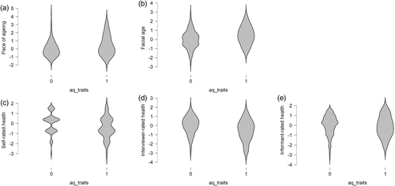

**FIGURE 1**

Violin plots comparing participants with high (label 1) and low (label 0) autistic traits. The y-axis is the standardized score of each variable and indicates the probability of observing that score in each group (wider plot indicates greater probability of observing that particular z-score). Plot (a) pace of aging at age 45; (b) facial age at 45; (c) self-rated health at 45; (d) interviewer-rated health at 45; and (e) informant-rated health at 45

### *Are autistic traits associated with faster aging and poorer health over and above sex, IQ, and SES?*

To test the hypothesis that autistic traits statistically predict aging and health variables, over and above the effects of sex, childhood IQ and SES, a series of multiple regression models were run. Model 1 included sex, childhood SES, and childhood IQ. Model 2 was identical to model 1 except dimensional autistic traits were included as a predictor of health and aging variables. Models 1 and 2 were significant for each dependent variable; moreover, the change in variance explained by adding autistic traits was significant for each dependent variable. Variance explained for Model 2 ranged from 2.8% (for informant-rated health) to 13.5% (for interviewer-rated health). Being female was a significant statistical predictor of worse self-rated health, but better interviewer-rated health. People with higher childhood IQ or SES tended to have a slower pace of aging and younger facial age, and higher self-, informant-, and interviewer-rated health. Finally, those with more autistic traits tended to have a faster pace of aging, older facial age, and poorer self-, informant-, and interviewer-rated health, over and above the effects of childhood IQ and SES. The results of the regression, including standardized β weights, are presented in Table 4 (See Table S2 for unstandardized B coefficients, with 95% confidence intervals).

TABLE 4. Results of the multiple regression analyses for the final model

|  | Pace of aging | Facial age | Self-rated health | Informant-rated health | Interviewer-rated health |
| --- | --- | --- | --- | --- | --- |
|  | Adjusted *R*<sup>2</sup> |  |  |  |  |
| Model 1<sup>a</sup> | 0.104*** | 0.085*** | 0.050*** | 0.015** | 0.110*** |
| Model 2<sup>b</sup> | 0.110*** | 0.089*** | 0.071*** | 0.028*** | 0.135*** |
| Predictors | Standardized β |  |  |  |  |
| Model 2 |  |  |  |  |  |
| *AQ traits* | 0.086* | 0.073* | −0.153*** | −0.122** | −0.170*** |
| *Sex* | −0.001 | 0.036 | −0.081* | 0.042 | 0.084** |
| *Childhood SES* | −0.147*** | −0.161*** | 0.119** | 0.091* | 0.157*** |
| *Childhood IQ* | −0.216*** | −0.170*** | 0.088* | 0.034 | 0.185*** |

- <sup>a</sup> Included sex, childhood SES, childhood IQ.
- <sup>b</sup> Included sex, childhood SES, childhood IQ, autistic traits.
- * *p* < 0.05;
- ** *p* < 0.01;
- *** *p* < 0.001.

## DISCUSSION

This study tested for the first time the hypothesis that autistic traits are associated with aging and physical health. Data from a population-representative cohort of nearly 1000 participants who had completed the AQ-10 measure of self-reported autistic traits at age 45 showed a significant correlation between autistic traits and measures of aging and physical health. In line with our hypotheses, regression models showed that a higher AQ-10 score was associated with faster aging and older facial age.

Importantly, autistic traits measured continuously at age 45 were still significantly associated with both the pace of aging and facial age scores even when controlling for childhood SES and IQ. Although modest, the correlation coefficients between the AQ-10 and both pace of aging and facial age are similar to those consistently reported between childhood IQ/SES and pace of aging in other studies (Belsky et al., 2017; Schaefer et al., 2016). Childhood SES is strongly associated with a range of physical health outcomes, irrespective of the SES one attains in adulthood (Poulton et al., 2002). However, our regression analyses suggest that autistic traits (measured dimensionally) may add a “cost” to aging over and above the effects of lower childhood IQ and SES. We also used the AQ-10 dichotomously, to characterize a small group of participants with high autistic traits; high and low trait groups showed significant differences in the aging/physical health measures in line with the correlational analyses.

Autistic traits statistically predicted poor physical health as reported by the participant, the interviewer, and an informant who knew the participant well. Considering the self-report data first, in samples of clinically diagnosed autistic people (Ayres et al., 2018), and non-autistic samples (Pisula et al., 2015), higher self-reported autistic traits are consistently associated with poorer quality of life (QOL) - a multidimensional construct that typically includes physical well-being/health (e.g., the WHOQoL-BREF; Whoqol Group, 1998). Specifically, Mason et al. (2018) found that, in a sample of autistic people, higher self-reported autistic traits were significantly associated with poorer physical QOL, and Lawson et al. (2020) found that autistic traits explained ~20% of the variance in physical QOL for their autistic participants.

Considering the informant- and interviewer-rated physical health findings, these suggest that characteristics associated with elevated autistic traits lead to summative judgments that physical well-being is not optimal. Researchers and informants may be influenced by apparent facial age in making their health judgments; facial age is used by clinicians as a source of information about health, as it reflects tissue integrity (Schaefer et al., 2016) and is a robust predictor of mortality in older cohorts (Christensen et al., 2009). Thus, those higher in autistic traits may be aging faster, which is reflected in how they look, which in turn affects how others judge their health. Taken together, then, the “cost” of higher autistic traits on aging and perceived health suggests that a short measure of autistic traits might possibly be a useful addition to existing physical health checks for older adults.

Several explanations could account for our findings. First, there may be polygenic effects underlying both aging and autistic traits. It may be that genetic factors underlying individual differences in the aging process, specifically for faster aging, overlap with the genetic loading for higher autistic traits. As aging largely occurs due to cells becoming less able to repair cellular damage (Adams & White 2004), it may be that these cellular mechanisms are less effective in those with a higher genetic propensity for autism. This could be tested with a polygenic score methodology, or by examining pace of aging in the first-degree relatives of autistic probands. This has not, to our knowledge, been done—although Stewart et al. (2020a) did compare health in older adults (aged 50+) with versus without a relative diagnosed with autism. They found higher rates of a range of mental health conditions (e.g., major depressive disorder and social anxiety), but not physical health conditions (e.g., high blood pressure, stroke, heart disease) except for endocrine conditions. Stewart et al. note that their volunteer sample may be an unusually healthy one; their reported prevalences for physical health conditions are lower than general population norms. Therefore, future work should examine putative genetic effects underlying both aging and autistic traits.

A second explanation could be that autistic traits impact lifestyle in a way that hastens aging. For example, autistic adults typically report reduced social networks (Howlin & Magiati, 2017). In older typically developing samples a link between social isolation and unhealthy lifestyles (such as smoking, or inactivity) has been reported (Kobayashi & Steptoe, 2018). Further, a recent meta-analysis found that loneliness was a risk factor for all-cause mortality (Rico-Uribe et al., 2018). Thus, if those with higher autistic traits are susceptible to impoverished social networks, and similar concomitant behaviors, it seems reasonable to conclude that the consequence will be poorer health and aging outcomes.

A third possible explanation for more rapid aging in those with elevated autistic traits might relate to common comorbidities associated with autism/autistic traits. In clinical samples of diagnosed autistic people these include sleep problems in childhood (Verhoeff et al., 2018) and adulthood (Ballester et al., 2019); and poor mental health, particularly increased rates of anxiety and depression (Croen et al., 2015; Howlin & Magiati, 2017). Quality of sleep has been linked to physical and mental function (Stanley, 2005) and facial aging (Oyetakin-White et al., 2015). In the general population, comparing older adults with versus without high autistic traits, Stewart et al. (2020b) found the high trait group reported more sleep problems, even after adjusting for their higher levels of depression and anxiety.

A fourth explanation might operate through life events and experiences. Autistic people are subject to higher rates of bullying, victimization, and stigma (Van Roekel et al., 2010). Thus, higher autistic traits may be correlated with an increased allostatic load, from multiple stressor sources, that consequently accelerates aging (Seeman et al., 2010). Testing these four hypotheses is beyond the scope of the current paper but could be addressed in future studies.

In our introduction, we describe the literature on health conditions for autistic people. This study presents an analysis of autistic traits in a large, representative sample general population sample. It seems appropriate, therefore, to consider to what degree our findings can be generalized to the autistic population. First, this study is based on the gathering evidence that autistic traits are continuously distributed and those with an autism diagnosis lie at the tail of this distribution (Spiker et al., 2002). However, some authors argue that autism trait studies do not necessarily address key issues about diagnosed autism (Mottron & Bzdok, 2020). As this issue is still not resolved, replicating these findings in autistic samples is essential. Second, it is important to consider that the variance explained by each regression model is small, at around 10%. Therefore, there are clearly many other factors relating to the aging and health variables presented here. Thus, it is likely that elevated autistic traits are one of many indicators for poorer aging and health outcomes. Third, we did not analyze the role of medication in this study. There are noted adverse metabolic effects from using psychotropic medication (Bhuvaneswar et al., 2009) which may affect the aging process; although in the Dunedin cohort, pace of aging was not affected by antipsychotic medication use (Wertz et al., 2021). Given that autistic people are often prescribed antipsychotic medication (both monopharmacy and polypharmacy) in childhood (Spencer et al., 2013) and adulthood (Esbensen et al., 2009), studies seeking to replicate these findings in clinical samples will need to pay careful attention to the role of medication. In sum, while these preliminary findings highlight a potential warning sign for poorer aging and health outcomes, it is essential to highlight that the present findings need replication with samples of diagnosed autistic adults, and that the effect of autistic traits on aging and health outcomes needs more exploration in the context of other relevant variables (such as medication). A final point, related to the preceeding points, is the type of aging trajectory we may expect in older age. The participants in this study were all aged 45 years of age, but we would wish to find out about aging in older autistic people (i.e., those aged 50 plus). We do not know if the more rapid aging associated with autistic traits will continue into older age, or if the association will become stronger or more attenuated. Future Dunedin research studies can examine this association over time.

## STRENGTHS AND LIMITATIONS

The Dunedin study is a birth cohort study that has been running for close to five decades. The retention rate of the cohort is excellent (Poulton et al., 2015). The cohort is well characterized, and representative of the wider New Zealand population of European descent. Thus, the findings from the study are likely generalizable to European-ancestry populations. This study uses a composite aging variable, derived from 19 biomarkers that have been collected longitudinally. This is important as some studies have found null results when examining a single biomarker for aging in the general population (e.g., between SES and telomere length; Adams et al., 2007). It is therefore essential to measure aging with multiple physiological measures over time.

The study used a brief form of the Autism Quotient to measure autistic traits at age 45. This is a widely used screening tool for ASD with multiple studies supporting its measurement properties (but see Baghdadli et al., 2017 for a review). We cannot be sure, however, that elevated AQ-10 scores do not reflect other types of difficulty instead of autism traits. For example, the items “I find it easy to do more than one thing at once” and “If there is an interruption, I can switch back to what I was doing very quickly” may tap executive dysfunction that is not uniquely associated with autism (Chang et al., 2020). Moreover, it is a limitation of this research that the AQ-10 or a similar autism trait measure was not collected when the Dunedin participants were children, however, in the 1970s the prevalence of autism was estimated to be less than 0.5 in 1000 (Gillberg & Wing, 1999), and for that reason it was never assessed. Thus, given the relative “youth” of the autism diagnosis, future studies could attempt to replicate these findings in samples of diagnosed autistic adults. Levels of autistic traits have been reported to be stable across time, in the general population, in both low and high scoring groups, in childhood to early adolescence (Robinson, Munir, et al., 2011; Whitehouse et al., 2011). Another general population study by Taylor et al. (2017) reported a phenotypic stability of 0.39 between the ages of 9 and 18 years. It is important to note, however, that the stability of autistic traits into adulthood and older age has yet to be reported. It could be that a few items on the AQ-10 could be affected by aging—for example, “I often notice small sounds when others do not” may be affected by age-related hearing loss (we would expect those higher in autistic traits to be more likely to endorse this item, so age-related hearing loss would not be a confound that could explain higher scores). Longitudinal studies using standardized measures of autistic traits and health outcomes could explore these possibilities with samples of older autistic people. Future work exploring aging and health—including measures of subjective quality of life, and alternative measures of autistic traits—using multi-dimensional measures, and exploring possible mediating factors, could elaborate on the associations reported here.

## CONCLUSION

Data were analyzed from the Dunedin Longitudinal Study; multiple regression analyses showed that autistic traits at age 45 were a statistical predictor of both biological aging and self- and informant-reports of physical health. Autistic traits explained variance in both aging and health variables beyond that explained by childhood SES and IQ. Given these findings, it seems that those with high autistic traits may be susceptible to poor health outcomes, as are diagnosed autistic people (Cashin et al., 2018; Croen et al., 2015), and may age faster in midlife. Given that signs of accelerated aging are evident at 45, and many chronic conditions of aging emerge later in life, the findings are concerning for the health of older people with high autistic traits. Thus, it is vital to improve healthcare and plan for healthy aging for both autistic people and those high in autistic traits.

## ACKNOWLEDGMENTS

We thank the members of the Advisory Board for the Dunedin Study, Dunedin Study members including their families and friends, Unit research staff, and Study founder Phil Silva, PhD, University of Otago. This research was supported by grants R01AG032282 and R01AG049789 from the National Institute on Aging and grant MR/P005918 from the UK Medical Research Council. Additional support was provided by the Jacobs Foundation, and New Zealand Health Research Council grant 15-265. The Dunedin Multidisciplinary Health and Development Study is supported by the New Zealand Health Research Council and New Zealand Ministry of Business, Innovation, and Employment. Dr. Wertz was supported by a postdoctoral fellowship from the AXA Research Fund.

## AUTHOR CONTRIBUTIONS

David Mason and Francesca Happé had full access to all of the data in the study and take responsibility for the integrity of the data and the accuracy of the data analysis. David Mason and Francesca Happé conceived the research question; all authors contributed to the design and analysis plan. David Mason completed the first draft of the manuscript, all authors contributed to final manuscript.

## ETHICAL APPROVAL

Written informed consent was obtained from cohort participants, and study protocols were approved by the institutional ethical review boards of the participating universities (ethics reference ref: 17/STH/25).

## Citing Literature

[figure not shown]

[Volume14, Issue8](https://onlinelibrary.wiley.com/toc/19393806/2021/14/8)

August 2021

Pages 1684-1694

### Recommended

  [Autism Research](https://onlinelibrary.wiley.com/journal/19393806)

[Download PDF](https://onlinelibrary.wiley.com/doi/pdf/10.1002/aur.2534)

[figure not shown]